# Distribution Viewer Pitch

2/10/2017

## The Probability Distribution Viewer

The Probability Distribution Viewer aims to give users the ability to:

- Randomly generate data points from 4 different probability distributions
- Select different characterstics of those probability distributions that they'd like it to satisfy
- And generate a graph of those distributions on the screen

## Overview

### Why Probability distributions?

In statistics, probability distributions (and densities) are a *fundamental* part to any statistical test. Therefore, understanding *what* a distribution is important. For example, a foundation of statistics, the linear model, is based on the assumption that the residuals from that model are **normally distributed**. [source](https://en.wikipedia.org/wiki/Ordinary_least_squares)

### Why Graphs?

Though the mathematical concepts behind probability distributions are vital to full understanding, a visual helps people get a more concrete example of how they shift and move rather than how they're abstractly represented. And in my personal opinion, I find graphs to be much more engaging and fun! (though not everyone may agree…)

## Graph vs Formulae

For example, the below items both represent normal distributions (PDFs). However,for a beginner, understanding how a distribution *looks* will provide more context then trying to understand how a distribution comes about (i.e. with the formula). Plus, doesn't the graph look more colorful and engaging as well?

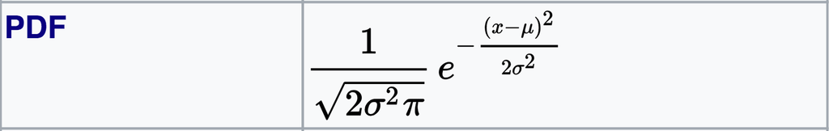

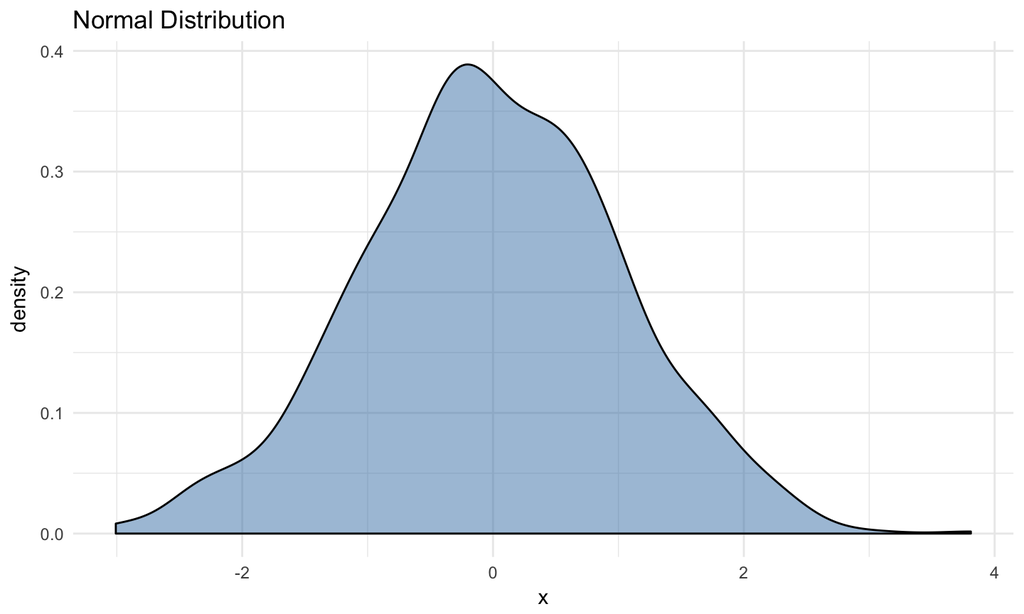

## Conclusion

Although mathematical formulas are necessary in order to advance in statistics, I believe that the ability for graphs to generate interest and engagement allows a much more effective avenue for introduction to probability densities

I hope that you enjoy using the Probability Density Viewer app, and the continuation of the Data Science Specialization!

[figure not shown]